# Project: Investigating the imdb-movies dataset

- Introduction
- Data Wrangling
- Exploratory Data Analysis
- Conclusions

## Introduction

### Dataset Description

> The IMDB movies dataset contains a list of movies, unique imdb id and other properties.The different columns in the dataset contains properties of the movie.IMDB(Internet Movie Database) is a web site that provides information about millions of films and television programs as well as their cast and directors. Below is the list of columns contained in the dataset and their meaning.
> - **id**- this is the unique number for a specific movie
> - **imdb_id**- this is imdb's unique number for each movie
> - **popularity**- The popularity rating of a particular title on IMDb indicates how much that title's page has been visited
> - **budget**- this is the amount of money spent to produce the movie
> - **Revenue**- this is amount made from sales of the movie
> - **original_title**- this is the title of the movie
> - **Cast**- these are the names of the actors and actresses in the movie
> - **Homepage**- this is website of the movie
> - **Director**- the name(s) of the directors of the movie
> - **tagline**- this is a short text which serves to clarify the movie
> - **keywords**- this is used to describe any notable object, concept, style or action that takes place during the movie
> - **overview**- this is used to summarize the film's storyline
> - **runtime**- this is time duration of the film in minutes
> - **genres**- this is categories that define a movie based on its narrative elements.
> - **production_companies**- this contains a list of companies that produced the movies
> - **release_date**- this is the date the film was released
> - **vote_count**- IMDb registered users can cast a vote (from 1 to 10) on every released title in the database
> - **vote_average**- this is the average of the vote count
> - **release_year**- this is the year the film was released
> - **budget_adj**- this is budget of the associated movie in terms of 2010 dollars, accounting for inflation over time
> - **revenue_adj**- this is the revenue of the associated movie in terms of 2010 dollars, accounting for inflation over time.

### Question(s) posed for Analysis

> *Almost everyone loves to watch movies right? i mean **'Netflix and chill'**.Upon loading and viewing this dataset, i am most willing to find out the answers to the questions posed below:*
> 1. **What is the relationship between the popularity rating of a movie and profit made from the movie?i mean, what is the correlation between how much is made from the film and its popularity?**

**what properties are associated with movies that make the most profit?**

**Has the profit made from each movie increased over the years?**

**what are the characteristics of the movie with the highest profit made?Who directed it?who are the casts of the Movie?Its runtime?**

```python
# Use this cell to set up import statements for all of the packages that you
#   plan to use.
import pandas as pd
import numpy as np
% matplotlib inline
import matplotlib.pyplot as plt
import seaborn as sns

# Remember to include a 'magic word' so that your visualizations are plotted
#   inline with the notebook. See this page for more:
#   http://ipython.readthedocs.io/en/stable/interactive/magics.html
```

```python
# Upgrade pandas to use dataframe.explode() function.
!pip install --upgrade pandas==0.25.0
```

[output not shown]

## Data Wrangling

**Data wrangling involves gathering, assessing and cleaning my dataset. The steps below aims to do exactly that.

### General Properties

Here, i loaded the data set and inspected it

```python
# i loaded my data and print out a few lines.
df = pd.read_csv('tmdb-movies.csv')
df.head(1)
```

|  | id | imdb_id | popularity | budget | revenue | original_title | cast | homepage | director | tagline | ... | overview | runtime | genres | production_companies | release_date | vote_count | vote_average | release_year | budget_adj | revenue_adj |
| --- | --- | --- | --- | --- | --- | --- | --- | --- | --- | --- | --- | --- | --- | --- | --- | --- | --- | --- | --- | --- | --- |
| 0 | 135397 | tt0369610 | 32.985763 | 150000000 | 1513528810 | Jurassic World | Chris Pratt\|Bryce Dallas Howard\|Irrfan Khan\|Vi... | http://www.jurassicworld.com/ | Colin Trevorrow | The park is open. | ... | Twenty-two years after the events of Jurassic ... | 124 | Action\|Adventure\|Science Fiction\|Thriller | Universal Studios\|Amblin Entertainment\|Legenda... | 6/9/15 | 5562 | 6.5 | 2015 | 1.379999e+08 | 1.392446e+09 |

1 rows × 21 columns

## Assessing my data

*Upon loading the data, i will like to inspect the various columns for unique, missing and irrelevant values*

*i will also be looking at the relevancy of my columns to the questions posed.*

```python
#firstly, i am using this code to check the dimension of my dataset.
df.shape
```

```
(10866, 21)
```

#### *Now that i have checked for the number of samples and columns in my dataset, i would be inspecting the dataset with the codes to follow below:*

```python
#this code checks for the characteristics of my dataset using the info() method
df.info()
```

```
<class 'pandas.core.frame.DataFrame'>
RangeIndex: 10866 entries, 0 to 10865
Data columns (total 21 columns):
id                      10866 non-null int64
imdb_id                 10856 non-null object
popularity              10866 non-null float64
budget                  10866 non-null int64
revenue                 10866 non-null int64
original_title          10866 non-null object
cast                    10790 non-null object
homepage                2936 non-null object
director                10822 non-null object
tagline                 8042 non-null object
keywords                9373 non-null object
overview                10862 non-null object
runtime                 10866 non-null int64
genres                  10843 non-null object
production_companies    9836 non-null object
release_date            10866 non-null object
vote_count              10866 non-null int64
vote_average            10866 non-null float64
release_year            10866 non-null int64
budget_adj              10866 non-null float64
revenue_adj             10866 non-null float64
dtypes: float64(4), int64(6), object(11)
memory usage: 1.7+ MB
```

**Null values affects data analysis. Hence, i will check for null values in my dataset and i will drop them durning my cleaning proccess**

```python
#this code checks for the sum of null values in each columns

df.isna().sum()
```

```
id                         0
imdb_id                   10
popularity                 0
budget                     0
revenue                    0
original_title             0
cast                      76
homepage                7930
director                  44
tagline                 2824
keywords                1493
overview                   4
runtime                    0
genres                    23
production_companies    1030
release_date               0
vote_count                 0
vote_average               0
release_year               0
budget_adj                 0
revenue_adj                0
dtype: int64
```

```python
#this code checks for the sum of unique values in my columns
df.nunique()
```

```
id                      10865
imdb_id                 10855
popularity              10814
budget                    557
revenue                  4702
original_title          10571
cast                    10719
homepage                 2896
director                 5067
tagline                  7997
keywords                 8804
overview                10847
runtime                   247
genres                   2039
production_companies     7445
release_date             5909
vote_count               1289
vote_average               72
release_year               56
budget_adj               2614
revenue_adj              4840
dtype: int64
```

#### RELEVANCY OF COLUMNS TO QUESTION POSED

**Below is the list of columns i will be dropping:**

#### 1. homepage

#### 2. keywords

#### 3. tagline

#### 4. production_companies

#### 5. overview

**Next, i will be checking for duplicates in my primary keys which are the 'id' and 'imdb_id' columns. This is because i should not have any two of these values for one movie**

```python
#this code check for sum of duplicate values in my imdb_id column
df['imdb_id'].duplicated().sum()
```

```
10
```

```python
#this code check for sum of duplicate values in my id column
df['id'].duplicated().sum()
```

```
1
```

### Inspecting DataTypes.

**Next, i will be checking the datatype of each column for incorrect data types**

```python
#this code checks the datatypes of the different columns in my dataset
df.dtypes
```

```
id                        int64
imdb_id                  object
popularity              float64
budget                    int64
revenue                   int64
original_title           object
cast                     object
homepage                 object
director                 object
tagline                  object
keywords                 object
overview                 object
runtime                   int64
genres                   object
production_companies     object
release_date             object
vote_count                int64
vote_average            float64
release_year              int64
budget_adj              float64
revenue_adj             float64
dtype: object
```

**I realized that my 'release_date' column should not be a object datatype, so durning my data cleaning proccess, i will be changing the incorrect data types.**

**In python, a string is represented as an object datatype, accounting for the columns having an object datatype**

### Data Cleaning

**Firstly, i will be dropping irrelevant columns identified while assessing my Dataset. You can check the questions posed here**

```python
#this code is used to drop columns irrelevant to answering the questions posed for this data.
df.drop(columns = ['homepage', 'keywords', 'tagline', 'overview', 'production_companies'], inplace = True)

df.head(1) #this checks to confirm that the columns have actually been dropped
```

|  | id | imdb_id | popularity | budget | revenue | original_title | cast | director | runtime | genres | release_date | vote_count | vote_average | release_year | budget_adj | revenue_adj |
| --- | --- | --- | --- | --- | --- | --- | --- | --- | --- | --- | --- | --- | --- | --- | --- | --- |
| 0 | 135397 | tt0369610 | 32.985763 | 150000000 | 1513528810 | Jurassic World | Chris Pratt\|Bryce Dallas Howard\|Irrfan Khan\|Vi... | Colin Trevorrow | 124 | Action\|Adventure\|Science Fiction\|Thriller | 6/9/15 | 5562 | 6.5 | 2015 | 1.379999e+08 | 1.392446e+09 |

**Next, i will be checking the characteristics of the remaining columns**

```python
#this line of code checks the number of none null values and their respective datatypes in each columns
df.info()
```

```
<class 'pandas.core.frame.DataFrame'>
RangeIndex: 10866 entries, 0 to 10865
Data columns (total 16 columns):
id                10866 non-null int64
imdb_id           10856 non-null object
popularity        10866 non-null float64
budget            10866 non-null int64
revenue           10866 non-null int64
original_title    10866 non-null object
cast              10790 non-null object
director          10822 non-null object
runtime           10866 non-null int64
genres            10843 non-null object
release_date      10866 non-null object
vote_count        10866 non-null int64
vote_average      10866 non-null float64
release_year      10866 non-null int64
budget_adj        10866 non-null float64
revenue_adj       10866 non-null float64
dtypes: float64(4), int64(6), object(6)
memory usage: 1.3+ MB
```

```python
#this line of code checks for the sum of unique samples in each column
df.nunique()
```

```
id                10865
imdb_id           10855
popularity        10814
budget              557
revenue            4702
original_title    10571
cast              10719
director           5067
runtime             247
genres             2039
release_date       5909
vote_count         1289
vote_average         72
release_year         56
budget_adj         2614
revenue_adj        4840
dtype: int64
```

```python
#this code is to check the sum of null values in each column.
df.isna().sum()
```

```
id                 0
imdb_id           10
popularity         0
budget             0
revenue            0
original_title     0
cast              76
director          44
runtime            0
genres            23
release_date       0
vote_count         0
vote_average       0
release_year       0
budget_adj         0
revenue_adj        0
dtype: int64
```

**The next set of processes will be to drop all null values in the columns above**

```python
#this code drops the null values in imdb_id, cast, director and genres column.
df.dropna(subset = ['cast', 'imdb_id', 'genres', 'director'], inplace = True)

df.isna().sum()#this checks to confirm the above operation
```

```
id                0
imdb_id           0
popularity        0
budget            0
revenue           0
original_title    0
cast              0
director          0
runtime           0
genres            0
release_date      0
vote_count        0
vote_average      0
release_year      0
budget_adj        0
revenue_adj       0
dtype: int64
```

```python
#this code is used to check the characteristics of the dataset after dropping null values
df.info()
```

```
<class 'pandas.core.frame.DataFrame'>
Int64Index: 10727 entries, 0 to 10865
Data columns (total 16 columns):
id                10727 non-null int64
imdb_id           10727 non-null object
popularity        10727 non-null float64
budget            10727 non-null int64
revenue           10727 non-null int64
original_title    10727 non-null object
cast              10727 non-null object
director          10727 non-null object
runtime           10727 non-null int64
genres            10727 non-null object
release_date      10727 non-null object
vote_count        10727 non-null int64
vote_average      10727 non-null float64
release_year      10727 non-null int64
budget_adj        10727 non-null float64
revenue_adj       10727 non-null float64
dtypes: float64(4), int64(6), object(6)
memory usage: 1.4+ MB
```

```python
#this line of code checks for the number of unique values in my dataset
df.nunique()
```

```
id                10726
imdb_id           10726
popularity        10679
budget              552
revenue            4698
original_title    10434
cast              10661
director           5016
runtime             243
genres             2020
release_date       5872
vote_count         1289
vote_average         70
release_year         56
budget_adj         2602
revenue_adj        4835
dtype: int64
```

**From the number of the unique values above, i noticed the presence of a duplicate value in the 'id' and 'imbd_id' column**

**the next lines of code aims to fish out the duplicates and drop the second occurence**

```python
#this code check for sum of duplicate values in my id column
df['id'].duplicated().sum()
```

```
1
```

```python
#this code check for sum of duplicate values in my imdb_id column
df['imdb_id'].duplicated().sum()
```

```
1
```

```python
#this lines of code aims to show the rows where we have duplicate id and imbd_id values
id_d = df["id"]
df[id_d.isin(id_d[id_d.duplicated()])]
```

|  | id | imdb_id | popularity | budget | revenue | original_title | cast | director | runtime | genres | release_date | vote_count | vote_average | release_year | budget_adj | revenue_adj |
| --- | --- | --- | --- | --- | --- | --- | --- | --- | --- | --- | --- | --- | --- | --- | --- | --- |
| 2089 | 42194 | tt0411951 | 0.59643 | 30000000 | 967000 | TEKKEN | Jon Foo\|Kelly Overton\|Cary-Hiroyuki Tagawa\|Ian... | Dwight H. Little | 92 | Crime\|Drama\|Action\|Thriller\|Science Fiction | 3/20/10 | 110 | 5.0 | 2010 | 30000000.0 | 967000.0 |
| 2090 | 42194 | tt0411951 | 0.59643 | 30000000 | 967000 | TEKKEN | Jon Foo\|Kelly Overton\|Cary-Hiroyuki Tagawa\|Ian... | Dwight H. Little | 92 | Crime\|Drama\|Action\|Thriller\|Science Fiction | 3/20/10 | 110 | 5.0 | 2010 | 30000000.0 | 967000.0 |

```python
#here, i will be writing a line of code to drop the duplicate discovered above.
df.drop_duplicates(subset= 'id', keep='first', inplace=True)

#this code checks to confirm that there are no duplicate id in my dataset.
df['id'].duplicated().sum()
```

```
0
```

**Now, i wil be checking the characteristics of my data after performing the above operations**

```python
df.info()
```

```
<class 'pandas.core.frame.DataFrame'>
Int64Index: 10726 entries, 0 to 10865
Data columns (total 16 columns):
id                10726 non-null int64
imdb_id           10726 non-null object
popularity        10726 non-null float64
budget            10726 non-null int64
revenue           10726 non-null int64
original_title    10726 non-null object
cast              10726 non-null object
director          10726 non-null object
runtime           10726 non-null int64
genres            10726 non-null object
release_date      10726 non-null object
vote_count        10726 non-null int64
vote_average      10726 non-null float64
release_year      10726 non-null int64
budget_adj        10726 non-null float64
revenue_adj       10726 non-null float64
dtypes: float64(4), int64(6), object(6)
memory usage: 1.4+ MB
```

**The next operation aims to create a column, indicating the name of the month from the 'release_date' column, all in relationship to the questions posed.**

```python
#this line of code is used to extract the number of the month from my column

df['month'] = df['release_date'].apply(lambda x: x[:-5].replace('/', '')).astype('int')
```

```python
#this lines of codes are used to create a column containing the name of the month for each release date.
month_n = ['January', 'February', 'March', 'April', 'May', 'June', 'July', 'August', 'September', 'October', 'November', 'December']

month_num = [1, 2, 3, 4, 5, 6, 7, 8, 9, 10, 11, 12]

#the code below maps the month number to month name
month_dict = dict(zip(month_num, month_n))

#the code below then links the month number column to the newy created dict, thereby returning the month name
df['month_name'] = df['month'].map(month_dict)
```

```python
#this line of code is used to confirm the operations performed above.
df.tail(1)
```

|  | id | imdb_id | popularity | budget | revenue | original_title | cast | director | runtime | genres | release_date | vote_count | vote_average | release_year | budget_adj | revenue_adj | month | month_name |
| --- | --- | --- | --- | --- | --- | --- | --- | --- | --- | --- | --- | --- | --- | --- | --- | --- | --- | --- |
| 10865 | 22293 | tt0060666 | 0.035919 | 19000 | 0 | Manos: The Hands of Fate | Harold P. Warren\|Tom Neyman\|John Reynolds\|Dian... | Harold P. Warren | 74 | Horror | 11/15/66 | 15 | 1.5 | 1966 | 127642.279154 | 0.0 | 11 | November |

```python
#this line of code aims to save the clean data up to this point
df.to_csv('clean_01.csv', index_label=False)
```

## Exploratory Data Analysis

### Univariate Analysis

**Here, i attempt to see the distribution and the composition of the data depending on the type of variable namely categorical or numerical.**

**Firstly, i will like to look at the general statistical description of relevant columns in my dataset**

```python
#this line of code computes a summary of statistics pertaining to the DataFrame columns.
df.describe()
```

[output not shown]

**From the above cell, i was able to know some statistical facts about my data, including the maximmum revenue generated by a movie**

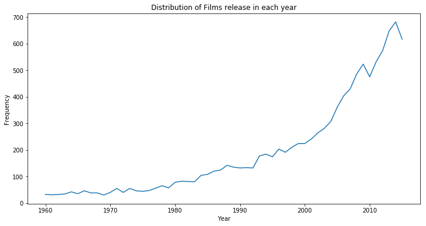

```python
#this line of code aims to check how much film is released in each year

df.groupby(['release_year']).size().plot(kind = 'line', figsize = (12,6));

plt.xlabel("Year");
plt.ylabel("Frequency");
plt.title("Distribution of Films release in each year");
```

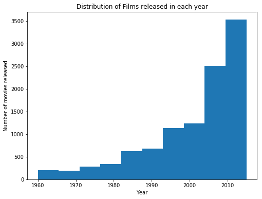

```python
#this line of code shows the distribution of films released each year
df['release_year'].plot(kind = 'hist', figsize = (8,6));
plt.xlabel("Year");
plt.ylabel("Number of movies released");
plt.title("Distribution of Films released in each year");
```

**From the chart plotted above, i noticed that my data is skewed to the left, which implies that the number of films released grew over the years**

**Next, i want to check the distribution of the samples with respect to their vote average**

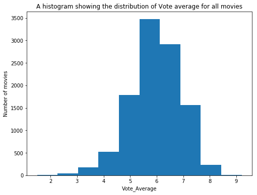

```python
#this lines of code plots the distribution of the vote average across the movies
df['vote_average'].plot(kind = 'hist', figsize = (8,6));
plt.xlabel("Vote_Average");
plt.ylabel("Number of movies");
plt.title("A histogram showing the distribution of Vote average for all movies");
```

**from the histogram above, it shows that most of the films have a vote average higher than 5.0**

**Next, i look at the number of movies released in each month of the year, in order to know how frequent a movie is released in any month of the year**

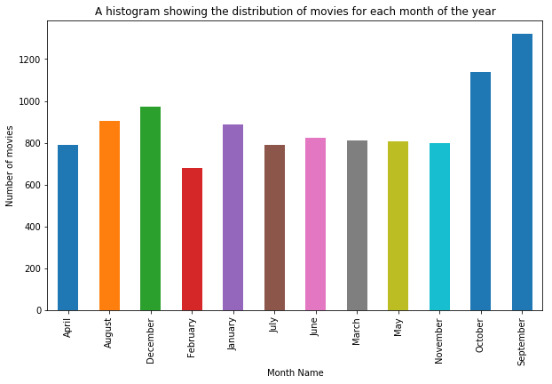

```python
#this lines of code plots the distribution of movies for each month of the year
df.groupby(['month_name']).id.count().plot(kind = 'bar', figsize = (10,6));
plt.xlabel("Month Name");
plt.ylabel("Number of movies");
plt.title("A histogram showing the distribution of movies for each month of the year");
```

**The bar plot above shows that highest number of movies were released in September**

### QUESTION 1: What is the relationship between the popularity rating of a movie and profit made from the movie?

**Next, i will like to group the popularity rating of the movie into different levels, with respect to their rating.This levels would be determined using the minimum, 25th, 50th, 75th percentile and its maximum value.**

```python
#this line of code describes the statistical facts of the popularity ratings
df.popularity.describe()
```

```
count    10726.000000
mean         0.652779
std          1.004995
min          0.000188
25%          0.210766
50%          0.387136
75%          0.721518
max         32.985763
Name: popularity, dtype: float64
```

**the next set of operations will be to create a label and group of numbers to quantify how popular a film is using the numbers between the max an minimum values.**

```python
# Numbers that will be used to "cut" the data into groups
Numbers = [0.000188, 0.210766 ,0.387136 , 0.721518 ,32.985763 ]
```

```python
# Labels for the four popularity groups
label_names = [ 'Not Popular','Slightly Popular' ,'Very Popular' ,'Most Popular' ]
```

```python
# Creates popularity levels column
df['popularity_levels'] = pd.cut(df['popularity'], Numbers, labels=label_names)

# Checks for successful creation of this column
df.head(1)
```

|  | id | imdb_id | popularity | budget | revenue | original_title | cast | director | runtime | genres | release_date | vote_count | vote_average | release_year | budget_adj | revenue_adj | month | month_name | popularity_levels |
| --- | --- | --- | --- | --- | --- | --- | --- | --- | --- | --- | --- | --- | --- | --- | --- | --- | --- | --- | --- |
| 0 | 135397 | tt0369610 | 32.985763 | 150000000 | 1513528810 | Jurassic World | Chris Pratt\|Bryce Dallas Howard\|Irrfan Khan\|Vi... | Colin Trevorrow | 124 | Action\|Adventure\|Science Fiction\|Thriller | 6/9/15 | 5562 | 6.5 | 2015 | 1.379999e+08 | 1.392446e+09 | 6 | June | Most Popular |

**In relationship to the question posed, i will be creating a column to calculate the profit made from each movie**

**i will then be looking at the profit adjusted due to inflation. Reason being that the only profit value that accurately accounts for the inflation is profit_adj. Hereby, making the profit for movies before 2010 equal in value to movies released after 2010, accounting for inflation**

```python
#this code aims to calculate the profit made from each movie, after accountin for inflation
df['profit'] = df['revenue'] - df['budget']

#this code aims to calculate the  adjusted profit made from each movie, accounting for inflation
df['profit_adj'] = df['revenue_adj'] - df['budget_adj']

df.head(5)#this line of code checks that the column has been created
```

|  | id | imdb_id | popularity | budget | revenue | original_title | cast | director | runtime | genres | ... | vote_count | vote_average | release_year | budget_adj | revenue_adj | month | month_name | popularity_levels | profit | profit_adj |
| --- | --- | --- | --- | --- | --- | --- | --- | --- | --- | --- | --- | --- | --- | --- | --- | --- | --- | --- | --- | --- | --- |
| 0 | 135397 | tt0369610 | 32.985763 | 150000000 | 1513528810 | Jurassic World | Chris Pratt\|Bryce Dallas Howard\|Irrfan Khan\|Vi... | Colin Trevorrow | 124 | Action\|Adventure\|Science Fiction\|Thriller | ... | 5562 | 6.5 | 2015 | 1.379999e+08 | 1.392446e+09 | 6 | June | Most Popular | 1363528810 | 1.254446e+09 |
| 1 | 76341 | tt1392190 | 28.419936 | 150000000 | 378436354 | Mad Max: Fury Road | Tom Hardy\|Charlize Theron\|Hugh Keays-Byrne\|Nic... | George Miller | 120 | Action\|Adventure\|Science Fiction\|Thriller | ... | 6185 | 7.1 | 2015 | 1.379999e+08 | 3.481613e+08 | 5 | May | Most Popular | 228436354 | 2.101614e+08 |
| 2 | 262500 | tt2908446 | 13.112507 | 110000000 | 295238201 | Insurgent | Shailene Woodley\|Theo James\|Kate Winslet\|Ansel... | Robert Schwentke | 119 | Adventure\|Science Fiction\|Thriller | ... | 2480 | 6.3 | 2015 | 1.012000e+08 | 2.716190e+08 | 3 | March | Most Popular | 185238201 | 1.704191e+08 |
| 3 | 140607 | tt2488496 | 11.173104 | 200000000 | 2068178225 | Star Wars: The Force Awakens | Harrison Ford\|Mark Hamill\|Carrie Fisher\|Adam D... | J.J. Abrams | 136 | Action\|Adventure\|Science Fiction\|Fantasy | ... | 5292 | 7.5 | 2015 | 1.839999e+08 | 1.902723e+09 | 12 | December | Most Popular | 1868178225 | 1.718723e+09 |
| 4 | 168259 | tt2820852 | 9.335014 | 190000000 | 1506249360 | Furious 7 | Vin Diesel\|Paul Walker\|Jason Statham\|Michelle ... | James Wan | 137 | Action\|Crime\|Thriller | ... | 2947 | 7.3 | 2015 | 1.747999e+08 | 1.385749e+09 | 4 | April | Most Popular | 1316249360 | 1.210949e+09 |

5 rows × 21 columns

**In the code cell below, i want to filter out the none zero profit on the dataset**

**I also would like to look at the relationship between movies that made at least 1000 and their popularity**

```python
#this line of code is used to filter out instance where we will have none zero profits
df_n = df[df.revenue > df.budget ]

#Here, i am treating zero budget as missing values, hence i filter out all zero budgets from my dataset
df_n2 = df_n[df_n.budget != 0]

#here, i filtered out profit size that is less than 1000
df_n3 = df_n2[df_n2.profit_adj >= 1000]

df_n3.head()
```

|  | id | imdb_id | popularity | budget | revenue | original_title | cast | director | runtime | genres | ... | vote_count | vote_average | release_year | budget_adj | revenue_adj | month | month_name | popularity_levels | profit | profit_adj |
| --- | --- | --- | --- | --- | --- | --- | --- | --- | --- | --- | --- | --- | --- | --- | --- | --- | --- | --- | --- | --- | --- |
| 0 | 135397 | tt0369610 | 32.985763 | 150000000 | 1513528810 | Jurassic World | Chris Pratt\|Bryce Dallas Howard\|Irrfan Khan\|Vi... | Colin Trevorrow | 124 | Action\|Adventure\|Science Fiction\|Thriller | ... | 5562 | 6.5 | 2015 | 1.379999e+08 | 1.392446e+09 | 6 | June | Most Popular | 1363528810 | 1.254446e+09 |
| 1 | 76341 | tt1392190 | 28.419936 | 150000000 | 378436354 | Mad Max: Fury Road | Tom Hardy\|Charlize Theron\|Hugh Keays-Byrne\|Nic... | George Miller | 120 | Action\|Adventure\|Science Fiction\|Thriller | ... | 6185 | 7.1 | 2015 | 1.379999e+08 | 3.481613e+08 | 5 | May | Most Popular | 228436354 | 2.101614e+08 |
| 2 | 262500 | tt2908446 | 13.112507 | 110000000 | 295238201 | Insurgent | Shailene Woodley\|Theo James\|Kate Winslet\|Ansel... | Robert Schwentke | 119 | Adventure\|Science Fiction\|Thriller | ... | 2480 | 6.3 | 2015 | 1.012000e+08 | 2.716190e+08 | 3 | March | Most Popular | 185238201 | 1.704191e+08 |
| 3 | 140607 | tt2488496 | 11.173104 | 200000000 | 2068178225 | Star Wars: The Force Awakens | Harrison Ford\|Mark Hamill\|Carrie Fisher\|Adam D... | J.J. Abrams | 136 | Action\|Adventure\|Science Fiction\|Fantasy | ... | 5292 | 7.5 | 2015 | 1.839999e+08 | 1.902723e+09 | 12 | December | Most Popular | 1868178225 | 1.718723e+09 |
| 4 | 168259 | tt2820852 | 9.335014 | 190000000 | 1506249360 | Furious 7 | Vin Diesel\|Paul Walker\|Jason Statham\|Michelle ... | James Wan | 137 | Action\|Crime\|Thriller | ... | 2947 | 7.3 | 2015 | 1.747999e+08 | 1.385749e+09 | 4 | April | Most Popular | 1316249360 | 1.210949e+09 |

5 rows × 21 columns

**Now using the dataset filtered out above, i will be looking at the total profit made from each level of popularity**

```python
#this line of code aims to group my dataset into different popularity levels
#and also gives the sum of profit made by each level

df_n3.groupby(['popularity_levels'], as_index = True)['profit', 'profit_adj'].sum()
```

| popularity_levels | profit | profit_adj |
| --- | --- | --- |
| Not Popular | 3130437342 | 5.180348e+09 |
| Slightly Popular | 5462768777 | 1.056350e+10 |
| Very Popular | 23478596846 | 3.641327e+10 |
| Most Popular | 254703570744 | 3.239484e+11 |

```python
#i created a variable for my grouped data

level_p = df_n3.groupby(['popularity_levels'], as_index = True)
```

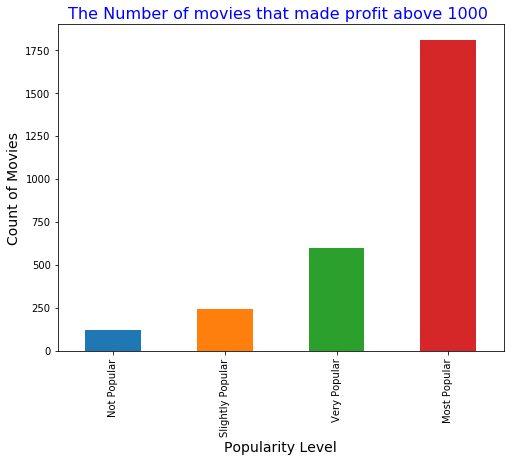

```python
#here i atempt to plot the grouped data, so as to show the distribution of movies for each popularity level

level_p.id.count().plot(kind = 'bar', figsize = (8,6));

plt.ylabel("Count of Movies", fontsize = 14);

plt.xlabel("Popularity Level", fontsize = 14);

plt.title("The Number of movies that made profit above 1000 ", fontsize = 16, color = 'blue');
```

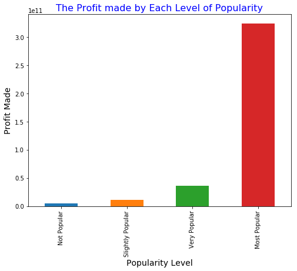

```python
#here i atempt to plot the grouped data, so as to show the distribution of profit_adj(inflation sake) for each popularity level

level_p['profit_adj'].sum().plot(kind = 'bar', figsize = (8,6));

plt.ylabel("Profit Made", fontsize = 14);

plt.xlabel("Popularity Level", fontsize = 14);

plt.title("The Profit made by Each Level of Popularity", fontsize = 16, color = 'blue');
```

**In order to visualize the relationship between the popularity ratings and the profit made off each movie, the next set of codes attempt to find the correlation between the two parameters using numpy and plotting the result on a scatter plot**

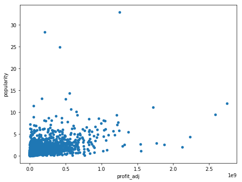

```python
#this code is used to plot a scatter plot showing the correlation between the two parameters specified.

df_n3.plot(x = 'profit_adj', y = 'popularity', kind = 'scatter', figsize = (8,6));
```

```python
#Here, I tried to show the correlation coefficient between the popularity and profit made from each movie

np.corrcoef(df_n3['popularity'], df_n3['profit'])
```

```
array([[ 1.       ,  0.5731893],
       [ 0.5731893,  1.       ]])
```

```python
#here, i also looked at the correlation between the popularity rating and the profit_adj column

np.corrcoef(df_n3['popularity'], df_n3['profit_adj'])
```

```
array([[ 1.        ,  0.48305983],
       [ 0.48305983,  1.        ]])
```

**In the course of trying to answer the question posed above, i discovered the following:**

- The most popular movies made the highest profit.
- Most of the movies that made profit > 1000 are the 'Most popular' movies
- There is a moderate positive correlation between the popularity rating of a movie and how much profit is made off it(Even after accounting for inflation using profit_adj column).

### QUESTION 2: what properties are associated with movies that make the most profit?

```python
# Continue to explore the data to address your additional research
#   questions. Add more headers as needed if you have more questions to
#   investigate.
```

**To answer the question above, i will be bringing in my dataset where i have the movies whose profit is greater than 1000**

**This filtered data was created while trying to answer the first question**

```python
#this line of code aims to show the dataset where profit_adj is greater than 1000

df_n3.head()
```

|  | id | imdb_id | popularity | budget | revenue | original_title | cast | director | runtime | genres | ... | vote_count | vote_average | release_year | budget_adj | revenue_adj | month | month_name | popularity_levels | profit | profit_adj |
| --- | --- | --- | --- | --- | --- | --- | --- | --- | --- | --- | --- | --- | --- | --- | --- | --- | --- | --- | --- | --- | --- |
| 0 | 135397 | tt0369610 | 32.985763 | 150000000 | 1513528810 | Jurassic World | Chris Pratt\|Bryce Dallas Howard\|Irrfan Khan\|Vi... | Colin Trevorrow | 124 | Action\|Adventure\|Science Fiction\|Thriller | ... | 5562 | 6.5 | 2015 | 1.379999e+08 | 1.392446e+09 | 6 | June | Most Popular | 1363528810 | 1.254446e+09 |
| 1 | 76341 | tt1392190 | 28.419936 | 150000000 | 378436354 | Mad Max: Fury Road | Tom Hardy\|Charlize Theron\|Hugh Keays-Byrne\|Nic... | George Miller | 120 | Action\|Adventure\|Science Fiction\|Thriller | ... | 6185 | 7.1 | 2015 | 1.379999e+08 | 3.481613e+08 | 5 | May | Most Popular | 228436354 | 2.101614e+08 |
| 2 | 262500 | tt2908446 | 13.112507 | 110000000 | 295238201 | Insurgent | Shailene Woodley\|Theo James\|Kate Winslet\|Ansel... | Robert Schwentke | 119 | Adventure\|Science Fiction\|Thriller | ... | 2480 | 6.3 | 2015 | 1.012000e+08 | 2.716190e+08 | 3 | March | Most Popular | 185238201 | 1.704191e+08 |
| 3 | 140607 | tt2488496 | 11.173104 | 200000000 | 2068178225 | Star Wars: The Force Awakens | Harrison Ford\|Mark Hamill\|Carrie Fisher\|Adam D... | J.J. Abrams | 136 | Action\|Adventure\|Science Fiction\|Fantasy | ... | 5292 | 7.5 | 2015 | 1.839999e+08 | 1.902723e+09 | 12 | December | Most Popular | 1868178225 | 1.718723e+09 |
| 4 | 168259 | tt2820852 | 9.335014 | 190000000 | 1506249360 | Furious 7 | Vin Diesel\|Paul Walker\|Jason Statham\|Michelle ... | James Wan | 137 | Action\|Crime\|Thriller | ... | 2947 | 7.3 | 2015 | 1.747999e+08 | 1.385749e+09 | 4 | April | Most Popular | 1316249360 | 1.210949e+09 |

5 rows × 21 columns

**Next, i will be looking at movies with profit_adj values higher than the median, and up to the maximum value**

**I will be tagging this range as the set of movies with the most profit made**

**I am using the profit_adj column in order to account for inflation for different movies released in different years**

```python
#this line of code calculates the summary statistics of the profit values
df_n3.profit_adj.describe()
```

```
count    2.762000e+03
mean     1.361714e+08
std      2.138278e+08
min      1.334861e+03
25%      2.076356e+07
50%      6.192046e+07
75%      1.560671e+08
max      2.750137e+09
Name: profit_adj, dtype: float64
```

**From the results show above, it shows that movies with profit_adj values higher than 62 million are those that made the most profit**

**Next, i will be filtering out the movies whose profit is greater than the median**

```python
#this line of code filters out the movies with profit value higher than or equal to 47 million
df_mp = df_n3[df_n3.profit_adj >= np.median(df_n3['profit_adj'])]

df_mp.head()
```

|  | id | imdb_id | popularity | budget | revenue | original_title | cast | director | runtime | genres | ... | vote_count | vote_average | release_year | budget_adj | revenue_adj | month | month_name | popularity_levels | profit | profit_adj |
| --- | --- | --- | --- | --- | --- | --- | --- | --- | --- | --- | --- | --- | --- | --- | --- | --- | --- | --- | --- | --- | --- |
| 0 | 135397 | tt0369610 | 32.985763 | 150000000 | 1513528810 | Jurassic World | Chris Pratt\|Bryce Dallas Howard\|Irrfan Khan\|Vi... | Colin Trevorrow | 124 | Action\|Adventure\|Science Fiction\|Thriller | ... | 5562 | 6.5 | 2015 | 1.379999e+08 | 1.392446e+09 | 6 | June | Most Popular | 1363528810 | 1.254446e+09 |
| 1 | 76341 | tt1392190 | 28.419936 | 150000000 | 378436354 | Mad Max: Fury Road | Tom Hardy\|Charlize Theron\|Hugh Keays-Byrne\|Nic... | George Miller | 120 | Action\|Adventure\|Science Fiction\|Thriller | ... | 6185 | 7.1 | 2015 | 1.379999e+08 | 3.481613e+08 | 5 | May | Most Popular | 228436354 | 2.101614e+08 |
| 2 | 262500 | tt2908446 | 13.112507 | 110000000 | 295238201 | Insurgent | Shailene Woodley\|Theo James\|Kate Winslet\|Ansel... | Robert Schwentke | 119 | Adventure\|Science Fiction\|Thriller | ... | 2480 | 6.3 | 2015 | 1.012000e+08 | 2.716190e+08 | 3 | March | Most Popular | 185238201 | 1.704191e+08 |
| 3 | 140607 | tt2488496 | 11.173104 | 200000000 | 2068178225 | Star Wars: The Force Awakens | Harrison Ford\|Mark Hamill\|Carrie Fisher\|Adam D... | J.J. Abrams | 136 | Action\|Adventure\|Science Fiction\|Fantasy | ... | 5292 | 7.5 | 2015 | 1.839999e+08 | 1.902723e+09 | 12 | December | Most Popular | 1868178225 | 1.718723e+09 |
| 4 | 168259 | tt2820852 | 9.335014 | 190000000 | 1506249360 | Furious 7 | Vin Diesel\|Paul Walker\|Jason Statham\|Michelle ... | James Wan | 137 | Action\|Crime\|Thriller | ... | 2947 | 7.3 | 2015 | 1.747999e+08 | 1.385749e+09 | 4 | April | Most Popular | 1316249360 | 1.210949e+09 |

5 rows × 21 columns

**The question is to find out the properties of the movies with the most profit**

**Hence, i will looking at the various distributions for the dataframe that contains the movies with the most profit**

```python
#this line of code returns the total number of columns and movies in this selected dataframe

df_mp.shape
```

```
(1381, 21)
```

**From the above result, i am able to know the number of movies that made the most profit which is = 1,381 movies**

```python
#here, i try to check for the distribution of the popularity levels of movies that made the most profit
pop_dist = df_mp.groupby(['popularity_levels']).size()

pop_dist
```

```
popularity_levels
Not Popular           18
Slightly Popular      45
Very Popular         169
Most Popular        1149
dtype: int64
```

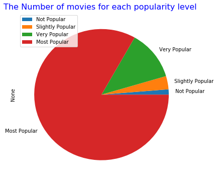

```python
#here, i try to plot the information garnered above on a pie chart

pop_dist.plot(kind = 'pie', figsize = (6,6));

plt.title("The Number of movies for each popularity level ", fontsize = 16, color = 'blue');

plt.legend();
```

**From above pie chart, one of the properties of movies in the selected dataset is that most of the movies are the "most popular" movies in the entire dataset**

**Next, I plot the distribution of movies that have the most profit for their month of release**

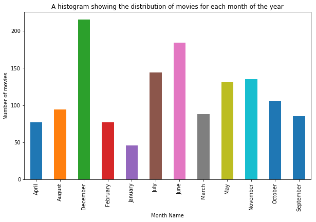

```python
#this lines of code plots the distribution of movies for each month of the year
df_mp.groupby(['month_name']).id.count().plot(kind = 'bar', figsize = (10,6));
plt.xlabel("Month Name");
plt.ylabel("Number of movies");
plt.title("A histogram showing the distribution of movies for each month of the year");
```

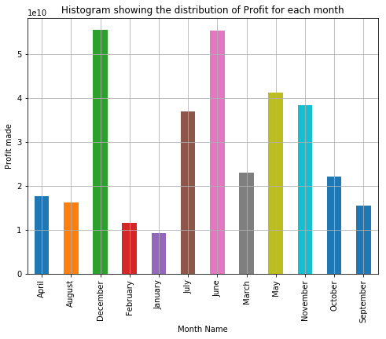

```python
#this line of code aims to find the total profit made in each month
df_mp.groupby(['month_name']).profit_adj.sum().plot( kind = 'bar', figsize = (8,6));

plt.xlabel("Month Name");
plt.ylabel("Profit made");
plt.title("Histogram showing the distribution of Profit for each month");

plt.grid(True)
```

**looking at the bar chart above, another property discovered is that movies released in the month of December and June made the highest Profit**

**Another property i am interested in is the vote average of the selected movies, and the codes that follow aims to find this out**

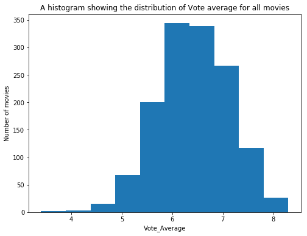

```python
#this lines of code plots the distribution of the vote average across the movies
df_mp['vote_average'].plot(kind = 'hist', figsize = (8,6));
plt.xlabel("Vote_Average");
plt.ylabel("Number of movies");
plt.title("A histogram showing the distribution of Vote average for all movies");
```

**From the above histogram, it shows that most of the movies in the selected dataset have a vote_average higher than 6.**

**In relation to the question posed about the properties of a group of movies that made the most profit, i performed EDA and below are some of what i found out:**

### Question 3:Has the profit made from each movie increased over the years?

**To answer this question, i will be grouping by the year of release for each movie**

**Next, i will be finding the sum of profit made in each year, after which i will plot this numbers on a line chart**

```python
#firstly, let me show the dataset i will be using
#this dataset contains profit_adj values greater than 1000
#this dataset was created in previous attempts to answer questions posed above

df_n3.head()
```

|  | id | imdb_id | popularity | budget | revenue | original_title | cast | director | runtime | genres | ... | vote_count | vote_average | release_year | budget_adj | revenue_adj | month | month_name | popularity_levels | profit | profit_adj |
| --- | --- | --- | --- | --- | --- | --- | --- | --- | --- | --- | --- | --- | --- | --- | --- | --- | --- | --- | --- | --- | --- |
| 0 | 135397 | tt0369610 | 32.985763 | 150000000 | 1513528810 | Jurassic World | Chris Pratt\|Bryce Dallas Howard\|Irrfan Khan\|Vi... | Colin Trevorrow | 124 | Action\|Adventure\|Science Fiction\|Thriller | ... | 5562 | 6.5 | 2015 | 1.379999e+08 | 1.392446e+09 | 6 | June | Most Popular | 1363528810 | 1.254446e+09 |
| 1 | 76341 | tt1392190 | 28.419936 | 150000000 | 378436354 | Mad Max: Fury Road | Tom Hardy\|Charlize Theron\|Hugh Keays-Byrne\|Nic... | George Miller | 120 | Action\|Adventure\|Science Fiction\|Thriller | ... | 6185 | 7.1 | 2015 | 1.379999e+08 | 3.481613e+08 | 5 | May | Most Popular | 228436354 | 2.101614e+08 |
| 2 | 262500 | tt2908446 | 13.112507 | 110000000 | 295238201 | Insurgent | Shailene Woodley\|Theo James\|Kate Winslet\|Ansel... | Robert Schwentke | 119 | Adventure\|Science Fiction\|Thriller | ... | 2480 | 6.3 | 2015 | 1.012000e+08 | 2.716190e+08 | 3 | March | Most Popular | 185238201 | 1.704191e+08 |
| 3 | 140607 | tt2488496 | 11.173104 | 200000000 | 2068178225 | Star Wars: The Force Awakens | Harrison Ford\|Mark Hamill\|Carrie Fisher\|Adam D... | J.J. Abrams | 136 | Action\|Adventure\|Science Fiction\|Fantasy | ... | 5292 | 7.5 | 2015 | 1.839999e+08 | 1.902723e+09 | 12 | December | Most Popular | 1868178225 | 1.718723e+09 |
| 4 | 168259 | tt2820852 | 9.335014 | 190000000 | 1506249360 | Furious 7 | Vin Diesel\|Paul Walker\|Jason Statham\|Michelle ... | James Wan | 137 | Action\|Crime\|Thriller | ... | 2947 | 7.3 | 2015 | 1.747999e+08 | 1.385749e+09 | 4 | April | Most Popular | 1316249360 | 1.210949e+09 |

5 rows × 21 columns

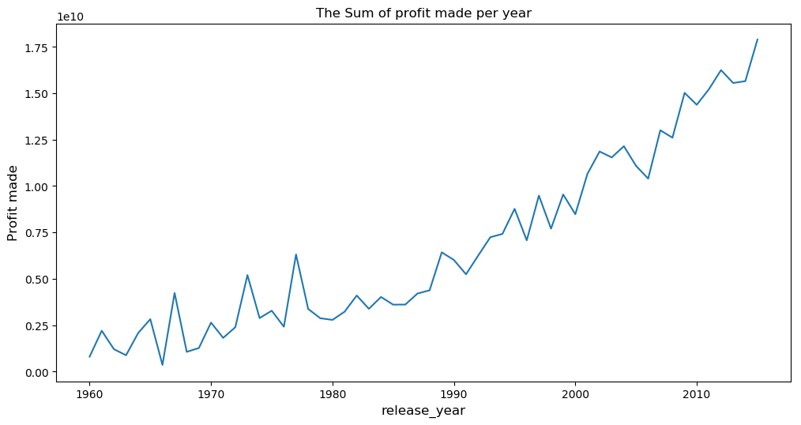

```python
#this line of code aims to group the dataset shown above by the release year and also sum up profit for each year

yearly_p = df_n3.groupby('release_year')['profit_adj'].sum()

#here, i aim to set my plot size and position
plt.figure(figsize=(12,6), dpi = 100)

#assign a label to x axis
plt.xlabel('release_year', fontsize = 12)
#assign a label to y axis
plt.ylabel('Profit made', fontsize = 12)
#the title of the line plot
plt.title('The Sum of profit made per year')

#this line code plots the line graph
plt.plot(yearly_p)

#this line of code shows the line plot
plt.show()
```

```python
#which year made the most profit?
yearly_p.idxmax()
```

```
2015
```

```python
#which year made the least profit?
yearly_p.idxmin()
```

```
1966
```

```python
#this line of code aims to find the difference between profit made in 1960 and 2015

print("The change in profit over the years(between 2015 and 1960) is :", format(yearly_p[2015] - yearly_p[1960]))
```

```
The change in profit over the years(between 2015 and 1960) is : 17094712871.992369
```

### Question 4: what are the characteristics of the movie with the highest profit made?Who directed it?who are the casts of the Movie?Its runtime?

**To answer the questions above, i will find out the movie with the highest profit**

**Hence, i will be using the 'profit_adj' column in order to have profit values of movies accounting for inflation, in terms of 2010 dollars**

```python
#this line of code attempts to load the group of data where the movies have at least 1000 dollars profit_adj
#this data set has been created in the process of answering previous questions

df_n3.head()
```

|  | id | imdb_id | popularity | budget | revenue | original_title | cast | director | runtime | genres | ... | vote_count | vote_average | release_year | budget_adj | revenue_adj | month | month_name | popularity_levels | profit | profit_adj |
| --- | --- | --- | --- | --- | --- | --- | --- | --- | --- | --- | --- | --- | --- | --- | --- | --- | --- | --- | --- | --- | --- |
| 0 | 135397 | tt0369610 | 32.985763 | 150000000 | 1513528810 | Jurassic World | Chris Pratt\|Bryce Dallas Howard\|Irrfan Khan\|Vi... | Colin Trevorrow | 124 | Action\|Adventure\|Science Fiction\|Thriller | ... | 5562 | 6.5 | 2015 | 1.379999e+08 | 1.392446e+09 | 6 | June | Most Popular | 1363528810 | 1.254446e+09 |
| 1 | 76341 | tt1392190 | 28.419936 | 150000000 | 378436354 | Mad Max: Fury Road | Tom Hardy\|Charlize Theron\|Hugh Keays-Byrne\|Nic... | George Miller | 120 | Action\|Adventure\|Science Fiction\|Thriller | ... | 6185 | 7.1 | 2015 | 1.379999e+08 | 3.481613e+08 | 5 | May | Most Popular | 228436354 | 2.101614e+08 |
| 2 | 262500 | tt2908446 | 13.112507 | 110000000 | 295238201 | Insurgent | Shailene Woodley\|Theo James\|Kate Winslet\|Ansel... | Robert Schwentke | 119 | Adventure\|Science Fiction\|Thriller | ... | 2480 | 6.3 | 2015 | 1.012000e+08 | 2.716190e+08 | 3 | March | Most Popular | 185238201 | 1.704191e+08 |
| 3 | 140607 | tt2488496 | 11.173104 | 200000000 | 2068178225 | Star Wars: The Force Awakens | Harrison Ford\|Mark Hamill\|Carrie Fisher\|Adam D... | J.J. Abrams | 136 | Action\|Adventure\|Science Fiction\|Fantasy | ... | 5292 | 7.5 | 2015 | 1.839999e+08 | 1.902723e+09 | 12 | December | Most Popular | 1868178225 | 1.718723e+09 |
| 4 | 168259 | tt2820852 | 9.335014 | 190000000 | 1506249360 | Furious 7 | Vin Diesel\|Paul Walker\|Jason Statham\|Michelle ... | James Wan | 137 | Action\|Crime\|Thriller | ... | 2947 | 7.3 | 2015 | 1.747999e+08 | 1.385749e+09 | 4 | April | Most Popular | 1316249360 | 1.210949e+09 |

5 rows × 21 columns

```python
#this lines of code is used to create a function to return all characteristics of the movie with the highest profit

import pprint#i imported this package in order to be able print my result

def calc_hp(column):#defining my function

    highest_p= df_n3[column].idxmax()#this code returns the maximum value in the column passed

    xteristics_hp=pd.DataFrame(df.loc[highest_p])#this code finds the characteristics of the max value gotten

    return xteristics_hp

calc_hp('profit_adj')
```

|  | 1329 |
| --- | --- |
| id | 11 |
| imdb_id | tt0076759 |
| popularity | 12.0379 |
| budget | 11000000 |
| revenue | 775398007 |
| original_title | Star Wars |
| cast | Mark Hamill\|Harrison Ford\|Carrie Fisher\|Peter ... |
| director | George Lucas |
| runtime | 121 |
| genres | Adventure\|Action\|Science Fiction |
| release_date | 3/20/77 |
| vote_count | 4428 |
| vote_average | 7.9 |
| release_year | 1977 |
| budget_adj | 3.95756e+07 |
| revenue_adj | 2.78971e+09 |
| month | 3 |
| month_name | March |
| popularity_levels | Most Popular |
| profit | 764398007 |
| profit_adj | 2.75014e+09 |

**I am most excited to return my findings for the question posed above:**

- The most profitable movie is Star Wars
- This movie was released on the 20th of March, 1977
- Accounting for inflation, in terms of 2010 dollars, the budget for this film is an ernormous 39 million and it made over 2 billion dollars😮
- The actual profit made in the year of release does not seem much at a sum of 764 million, but upon accounting for inflation, i see that this movie made a lot of profit
- The amazing director who directed this successful movie is George Lucas and the movie has a runtime of 121 minutes
- Talking about the cast of this amazing movie, we have Mark Hamill, Harrison Ford, Carrie Fisher ,Peter... etc

## Conclusions

**limitations include but not limited to the following:**

- The specific currency was not provided, hence durning the course of this analysis, all units were assumed to be in dollars
- The budget and revenue values being zero affected the analysis, causing me to remove over 50% of the samples with zero values in order to properly get the movies that actually made profit
- I performed this analysis by considering the movies which made profit of over 1000 dollars. This might not be completely error free

> **Tip**: Finally, summarize your findings and the results that have been performed in relation to the question(s) provided at the beginning of the analysis. Summarize the results accurately, and point out where additional research can be done or where additional information could be useful.

> **Tip**: Make sure that you are clear with regards to the limitations of your exploration. You should have at least 1 limitation explained clearly.

> **Tip**: If you haven't done any statistical tests, do not imply any statistical conclusions. And make sure you avoid implying causation from correlation!

> **Tip**: Once you are satisfied with your work here, check over your report to make sure that it is satisfies all the areas of the rubric (found on the project submission page at the end of the lesson). You should also probably remove all of the "Tips" like this one so that the presentation is as polished as possible.

## Submitting your Project

> **Tip**: Before you submit your project, you need to create a .html or .pdf version of this notebook in the workspace here. To do that, run the code cell below. If it worked correctly, you should get a return code of 0, and you should see the generated .html file in the workspace directory (click on the orange Jupyter icon in the upper left).

> **Tip**: Alternatively, you can download this report as .html via the **File** > **Download as** submenu, and then manually upload it into the workspace directory by clicking on the orange Jupyter icon in the upper left, then using the Upload button.

> **Tip**: Once you've done this, you can submit your project by clicking on the "Submit Project" button in the lower right here. This will create and submit a zip file with this .ipynb doc and the .html or .pdf version you created. Congratulations!

```python
from subprocess import call
call(['python', '-m', 'nbconvert', 'Investigate_a_Dataset.ipynb'])
```